# Recommendation Systems

2022-12-05

## Recommendation systems

- Recommendation systems use ratings that *users* have given *items* to make specific recommendations.
- Companies that sell many products to many customers and permit these customers to rate their products, like Amazon, are able to collect massive datasets that can be used to predict what rating a particular user will give a specific item.
- Items for which a high rating is predicted for a given user are then recommended to that user.
- Netflix uses a recommendation system to predict how many *stars* a user will give a specific movie.

## Recommendation systems

- One star suggests it is not a good movie, whereas five stars suggests it is an excellent movie.
- Here, we provide the basics of how these recommendations are made, motivated by some of the approaches taken by the winners of the *Netflix challenges*.
- In October 2006, Netflix offered a challenge to the data science community: improve our recommendation algorithm by 10% and win a million dollars.

## Recommendation systems

- In September 2009, the winners were announced<sup>1</sup>.
- You can read a good summary of how the winning algorithm was put together here: http://blog.echen.me/2011/10/24/winning-the-netflix-prize-a-summary/.
- and a more detailed explanation here:
- https://www2.seas.gwu.edu/~simhaweb/champalg/cf/papers/KorenBellKor2009.pdf.
- We will now show you some of the data analysis strategies used by the winning team.

## Movielens data

- The Netflix data is not publicly available, but the [GroupLens research lab](https://grouplens.org/) generated their own database with over 20 million ratings for over 27,000 movies by more than 138,000 users.
- We make a small subset of this data available via the **dslabs** package:

```r
library(tidyverse)
library(dslabs)
data("movielens")
```

## Movielens data

- We can see this table is in tidy format with thousands of rows:

```r
movielens |> as_tibble()
```

```
#> # A tibble: 100,004 × 7
#>    movieId title                             year genres userId rating timestamp
#>      <int> <chr>                            <int> <fct>   <int>  <dbl>     <int>
#>  1      31 Dangerous Minds                   1995 Drama       1    2.5    1.26e9
#>  2    1029 Dumbo                             1941 Anima…      1    3      1.26e9
#>  3    1061 Sleepers                          1996 Thril…      1    3      1.26e9
#>  4    1129 Escape from New York              1981 Actio…      1    2      1.26e9
#>  5    1172 Cinema Paradiso (Nuovo cinema P…  1989 Drama       1    4      1.26e9
#>  6    1263 Deer Hunter, The                  1978 Drama…      1    2      1.26e9
#>  7    1287 Ben-Hur                           1959 Actio…      1    2      1.26e9
#>  8    1293 Gandhi                            1982 Drama       1    2      1.26e9
#>  9    1339 Dracula (Bram Stoker's Dracula)   1992 Fanta…      1    3.5    1.26e9
#> 10    1343 Cape Fear                         1991 Thril…      1    2      1.26e9
#> # … with 99,994 more rows
```

- Each row represents a rating given by one user to one movie.

## Movielens data

- We can see the number of unique users that provided ratings and how many unique movies were rated:

```r
movielens |>
  summarize(n_users = n_distinct(userId),
            n_movies = n_distinct(movieId))
```

```
#>   n_users n_movies
#> 1     671     9066
```

- If we multiply those two numbers, we get a number larger than 5 million, yet our data table has about 100,000 rows.
- This implies that not every user rated every movie.

## Movielens data

- So we can think of these data as a very large matrix, with users on the rows and movies on the columns, with many empty cells.
- The `pivot_wider` function permits us to convert it to this format, but if we try it for the entire matrix, it will crash R.
- Let’s show the matrix for six users and four movies.

## Movielens data

| userId | Pulp Fiction | Shawshank Redemption | Forrest Gump | Silence of the Lambs |
| --- | --- | --- | --- | --- |
| 13 | 3.5 | 4.5 | 5.0 | NA |
| 15 | 5.0 | 2.0 | 1.0 | 5.0 |
| 16 | NA | 4.0 | NA | NA |
| 17 | 5.0 | 5.0 | 2.5 | 4.5 |
| 19 | 5.0 | 4.0 | 5.0 | 3.0 |
| 20 | 0.5 | 4.5 | 2.0 | 0.5 |

- You can think of the task of a recommendation system as filling in the `NA`s in the table above.

## Movielens data

- To see how *sparse* the matrix is, here is the matrix for a random sample of 100 movies and 100 users with yellow indicating a user/movie combination for which we have a rating.

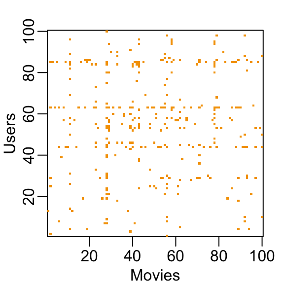

## Movielens data

- This machine learning challenge is more complicated than what we have studied up to now because each outcome \(Y\) has a different set of predictors.
- To see this, note that if we are predicting the rating for movie \(i\) by user \(u\), in principle, all other ratings related to movie \(i\) and by user \(u\) may be used as predictors, but different users rate different movies and a different number of movies.
- Furthermore, we may be able to use information from other movies that we have determined are similar to movie \(i\) or from users determined to be similar to user \(u\).
- In essence, the entire matrix can be used as predictors for each cell.

## Movielens data

- Let’s look at some of the general properties of the data to better understand the challenges.
- The first thing we notice is that some movies get rated more than others.
- Below is the distribution.
- This should not surprise us given that there are blockbuster movies watched by millions and artsy, independent movies watched by just a few.

## Movielens data

- Our second observation is that some users are more active than others at rating movies:

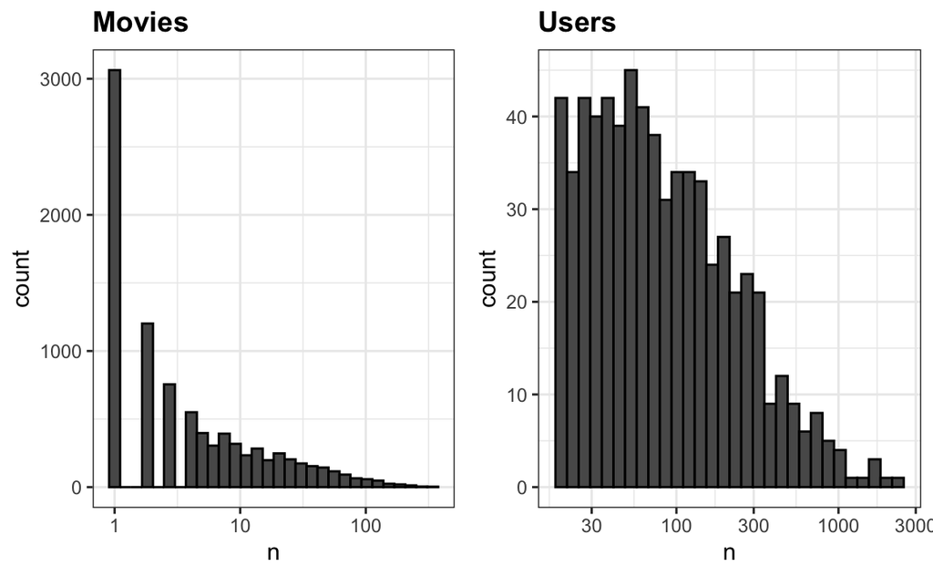

## Recommendation systems as a machine learning challenge

- To see how this is a type of machine learning, notice that we need to build an algorithm with data we have collected that will then be applied outside our control, as users look for movie recommendations.
- So let’s create a test set to assess the accuracy of the models we implement.

## Recommendation systems as a machine learning challenge

- We only consider movies rated five times or more, and users that have rated more than 100 of these movies.

```r
dat <- movielens |> group_by(movieId) |>
  mutate(n=n()) |>
  ungroup() |>
  filter(n >= 5) |>
  group_by(userId) |>
  mutate(n=n()) |>
  ungroup() |>
  filter(n >= 100) |>
  select(-n)
```

## Recommendation systems as a machine learning challenge

- We then split the data into a training set and test set by assiging 20% of the ratings made by each user to the test set:

```r
set.seed(2006)
indexes <- split(1:nrow(dat), dat$userId)
test_ind <- sapply(indexes, function(ind){
  sample(ind, ceiling(length(ind)*.2))}) |>
  unlist(use.names = TRUE) |> sort()
test_set <- dat[test_ind,]
train_set <- dat[-test_ind,]
```

## Recommendation systems as a machine learning challenge

- To make sure we don’t include users and movies in the test set that do not appear in the training set, we remove these entries using the `semi_join` function:

```r
test_set <- test_set |>
  semi_join(train_set, by = "movieId") |>
  semi_join(train_set, by = "userId")
```

## Recommendation systems as a machine learning challenge

- Finally we use `pivot_wider` to make a matrix with users represented by rows and movies by the columns.

```r
mat <- select(train_set, movieId, userId, rating) |>
  pivot_wider(names_from = movieId, values_from = rating)
rnames <- mat$userId
mat <- as.matrix(mat[,-1])
rownames(mat) <- rnames
```

- along with a table to map movie ids to titles:

```r
movie_map <- train_set |> select(movieId, title) |>
  distinct(movieId, .keep_all = TRUE)
```

## Loss function

- The Netflix challenge used the typical error loss: they decided on a winner based on the residual mean squared error (RMSE) on a test set.
- We define \(y_{u,i}\) as the rating for movie \(i\) by user \(u\) and denote our prediction with \(\hat{y}_{u,i}\).
- The RMSE is then defined as:

\[ \mbox{RMSE} = \sqrt{\frac{1}{N} \sum_{u,i}^{} \left( \hat{y}_{u,i} - y_{u,i} \right)^2 } \]

## Loss function

- with \(N\) being the number of user/movie combinations and the sum occurring over all these combinations.
- Remember that we can interpret the RMSE similarly to a standard deviation: it is the typical error we make when predicting a movie rating.
- If this number is larger than 1, it means our typical error is larger than one star, which is not good.

## Loss function

- Let’s write a function that computes the RMSE for vectors of ratings and their corresponding predictors:

```r
RMSE <- function(true_ratings, predicted_ratings){
    sqrt(mean((true_ratings - predicted_ratings)^2))
  }
```

## A first model

- Let’s start by building the simplest possible recommendation system: we predict the same rating for all movies regardless of user.
- What number should this prediction be? We can use a model based approach to answer this.
- A model that assumes the same rating for all movies and users with all the differences explained by random variation would look like this:

\[ Y_{u,i} = \mu + \varepsilon_{u,i} \]

- with \(\varepsilon_{i,u}\) independent errors sampled from the same distribution centered at 0 and \(\mu\) the “true” rating for all movies.

## A first model

- We know that the estimate that minimizes the RMSE is the least squares estimate of \(\mu\) and, in this case, is the average of all ratings:

```r
mu <- mean(mat, na.rm = TRUE)
mu
```

```
#> [1] 3.54
```

## A first model

- If we predict all unknown ratings with \(\hat{\mu}\) we obtain the following RMSE:

```r
naive_rmse <- RMSE(test_set$rating, mu)
naive_rmse
```

```
#> [1] 1.04
```

- Keep in mind that if you plug in any other number, you get a higher RMSE.

## A first model

- For example:

```r
predictions <- rep(3, nrow(test_set))
RMSE(test_set$rating, predictions)
```

```
#> [1] 1.17
```

- From looking at the distribution of ratings, we can visualize that this is the standard deviation of that distribution.
- We get a RMSE of about 1.

## A first model

- To win the grand prize of $1,000,000, a participating team had to get an RMSE of about 0.857.
- So we can definitely do better!.
- As we go along, we will be comparing different approaches.
- Let’s start by creating a results table with this naive approach:

```r
rmse_results <- tibble(method = "Just the average", RMSE = naive_rmse)
```

## Modeling movie effects

- We know from experience that some movies are just generally rated higher than others.
- This.
- intuition, that different movies are rated differently, is confirmed by data.
- We can augment our previous model by adding the term \(b_i\) to represent average ranking for movie \(i\):

\[ Y_{u,i} = \mu + b_i + \varepsilon_{u,i} \]

## Modeling movie effects

- Statistics textbooks refer to the \(b\)s as effects.
- However, in the Netflix challenge papers, they refer to them as *bias*, thus the \(b\) notation.
- We can again use least squares to estimate the \(b_i\) in the following way:

```r
fit <- lm(rating ~ as.factor(movieId), data = movielens)
```

- Because there are thousands of \(b_i\) as each movie gets one, the `lm()` function will be very slow here.
- We therefore don’t recommend running the code above.

## Modeling movie effects

- But in this particular situation, we know that the least squares estimate \(\hat{b}_i\) is just the average of \(Y_{u,i} - \hat{\mu}\) for each movie \(i\).
- So we can compute them this way (we will drop the `hat` notation in the code to represent estimates going forward):

```r
b_i <- colMeans(mat - mu, na.rm = TRUE)
```

## Modeling movie effects

- We can see that these estimates vary substantially:

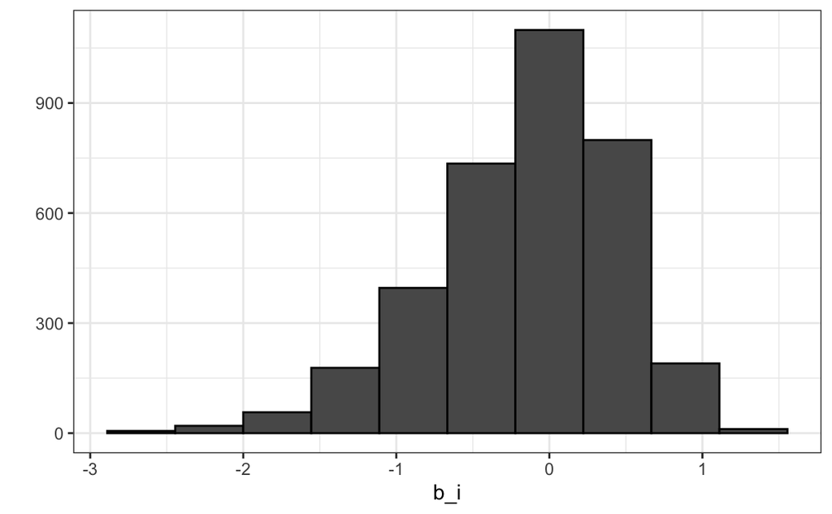

```r
qplot(b_i, bins = 10, color = I("black"))
```

- Remember \(\hat{\mu}=3.5\) so a \(b_i = 1.5\) implies a perfect five star rating.

## Modeling movie effects

- Let’s see how much our prediction improves once we use \(\hat{y}_{u,i} = \hat{\mu} + \hat{b}_i\):

```r
fit_movies <- data.frame(movieId = as.integer(colnames(mat)),
                         mu = mu, b_i = b_i)
left_join(test_set, fit_movies, by = "movieId") |>
  mutate(pred = mu + b_i) |>
  summarize(rmse = RMSE(rating, pred))
```

```
#> # A tibble: 1 × 1
#>    rmse
#>   <dbl>
#> 1 0.970
```

- We already see an improvement.
- But can we make it better?

## User effects

- Let’s compute the average rating for user \(u\) for those that have rated 100 or more movies:

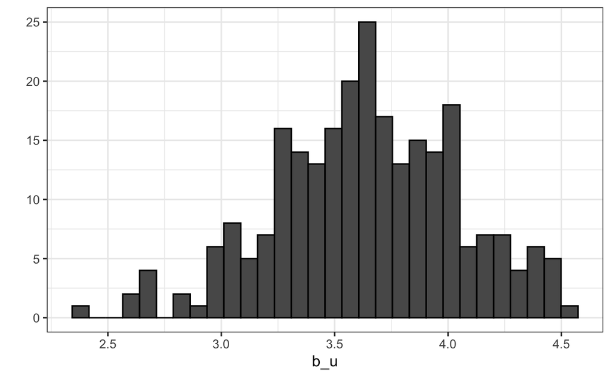

```r
b_u <- rowMeans(mat, na.rm = TRUE)
qplot(b_u, bins = 30, color = I("black"))
```

## User effects

- Notice that there is substantial variability across users.
- as well: some users are very cranky and others love every movie.
- This implies that a further improvement to our model may be:

\[ Y_{u,i} = \mu + b_i + b_u + \varepsilon_{u,i} \]

- where \(b_u\) is a user-specific effect.

## User effects

- Now if a cranky user (negative \(b_u\)) rates a great movie (positive \(b_i\)), the effects counter each other and we may be able to correctly predict that this user gave this great movie a 3 rather than a 5.
- To fit this model, we could again use `lm` like this:

```r
lm(rating ~ as.factor(movieId) + as.factor(userId))
```

- but, for the reasons described earlier, we won’t.

## User effects

- Instead, we will compute an approximation by computing \(\hat{\mu}\) and \(\hat{b}_i\) and estimating \(\hat{b}_u\) as the average of \(y_{u,i} - \hat{\mu} - \hat{b}_i\):

```r
b_u <- rowMeans(sweep(mat - mu, 2, b_i), na.rm = TRUE)
```

- We can now construct predictors and see how much the RMSE improves:

```r
fit_users <- data.frame(userId = as.integer(rownames(mat)), b_u = b_u)
left_join(test_set, fit_movies, by = "movieId") |>
  left_join(fit_users, by = "userId") |>
  mutate(pred = mu + b_i + b_u) |>
  summarize(rmse = RMSE(rating, pred))
```

```
#> # A tibble: 1 × 1
#>    rmse
#>   <dbl>
#> 1 0.885
```

## Regularization

- Let’s look at the top 3 movies, based on our estimates of the movie effect \(b_i\), along with the number of ratings this rating was based on.

```r
n <-  colSums(!is.na(mat))
fit_movies$n <- n
best <- fit_movies |> left_join(movie_map, by = "movieId") |>
  top_n(3, b_i) |>
  arrange(desc(b_i)) |>
  mutate(average_rating = mu + b_i)
best |>  select(title, average_rating, n)
```

```
#>          title average_rating n
#> 1    Kagemusha           5.00 2
#> 2 Flash Gordon           5.00 2
#> 3     Paperman           4.88 4
```

- These all seem like obscure movies.

## Motivation

- Do we really think these are the top 3 movies in our database? Will this prediction hold on the test set? Note that all lower in the test, some considerable lower:

```r
test_set |>
  group_by(movieId) |>
  summarize(averge_rating_test = mean(rating)) |>
  right_join(best, by = "movieId") |>
  select(title, average_rating, averge_rating_test, n)
```

```
#> # A tibble: 3 × 4
#>   title        average_rating averge_rating_test     n
#>   <chr>                 <dbl>              <dbl> <dbl>
#> 1 Kagemusha              5                   4       2
#> 2 Flash Gordon           5                   2.3     2
#> 3 Paperman               4.88                4.5     4
```

- Note that these estimates are based on a small number of ratings. The supposed *best* movies were rated by very few users.

## Motivation

- Note that the small sample sizes lead to uncertainty.
- Therefore, larger estimates of \(b_i\), negative or positive, are more likely.
- These are noisy estimates that we should not trust, especially when it comes to prediction.
- Large errors can ncrease our RMSE, so we would rather be conservative when unsure.

## Motivation

- In previous sections, we computed standard error and constructed confidence intervals to account for different levels of uncertainty.
- However, when making predictions, we need one number, one prediction, not an interval.
- For this, we introduce the concept of regularization.
- Regularization permits us to penalize large estimates that are formed using small sample sizes.
- It has commonalities with the Bayesian approach that shrunk predictions.

## Penalized least squares

- The general idea behind regularization is to constrain the total variability of the effect sizes.
- Why does this help? Consider a case in which we have movie \(i=1\) with 100 user ratings and 4 movies \(i=2,3,4,5\) with just one user rating.
- We intend to fit the model.

\[ Y_{u,i} = \mu + b_i + \varepsilon_{u,i} \]

- Suppose we know the average rating is, say, \(\mu = 3\).

## Penalized least squares

- If we use least squares, the estimate for the first movie effect \(b_1\) is the average of the 100 user ratings, \(1/100 \sum_{i=1}^{100} (Y_{i,1} - \mu)\), which we expect to be a quite precise.
- However, the estimate for movies 2, 3, 4, and 5 will simply be the observed deviation from the average rating \(\hat{b}_i = Y_{u,i} - \hat{\mu}\) which is an estimate based on just one number so it won’t be precise at all.
- Note these estimates make the error \(Y_{u,i} - \mu + \hat{b}_i\) equal to 0 for \(i=2,3,4,5\), but this is a case of over-training.

## Penalized least squares

- In fact, ignoring the one user and guessing that movies 2,3,4, and 5 are just average movies (\(b_i = 0\)) might provide a better prediction.
- The general idea of penalized regression is to control the total variability of the movie effects: \(\sum_{i=1}^5 b_i^2\).
- Specifically, instead of minimizing the least squares equation, we minimize an equation that adds a penalty:

\[ \sum_{u,i} \left(y_{u,i} - \mu - b_i\right)^2 + \lambda \sum_{i} b_i^2 \]

## Penalized least squares

- The first term is just the sum of squares and the second is a penalty that gets larger when many \(b_i\) are large.
- Using calculus we can actually show that the values of \(b_i\) that minimize this equation are:

\[ \hat{b}_i(\lambda) = \frac{1}{\lambda + n_i} \sum_{u=1}^{n_i} \left(Y_{u,i} - \hat{\mu}\right) \]

- where \(n_i\) is the number of ratings made for movie \(i\).

## Penalized least squares

- This approach will have our desired effect: when our sample size \(n_i\) is very large, a case which will give us a stable estimate, then the penalty \(\lambda\) is effectively ignored since \(n_i+\lambda \approx n_i\).
- However, when the \(n_i\) is small, then the estimate \(\hat{b}_i(\lambda)\) is shrunken towards 0.
- The larger \(\lambda\), the more we shrink.

## Penalized least squares

- To select \(\lambda\), we can use cross validation:

```r
lambdas <- seq(0, 10, 0.25)
rmses <- sapply(lambdas, function(lambda){
  b_i <- colSums(mat - mu, na.rm = TRUE) / (n + lambda)
  fit <- data.frame(movieId = as.integer(colnames(mat)), mu = mu, b_i = b_i)
  left_join(test_set, fit, by = "movieId") |> mutate(pred = mu + b_i) |>
    summarize(rmse = RMSE(rating, pred)) |>
    pull(rmse)
})
```

## Penalized least squares

- We can then select the value that minimizes the RMSE:

```r
qplot(lambdas, rmses)
lambda <- lambdas[which.min(rmses)]
print(lambda)
```

## Penalized least squares

```
#> [1] 3.5
```

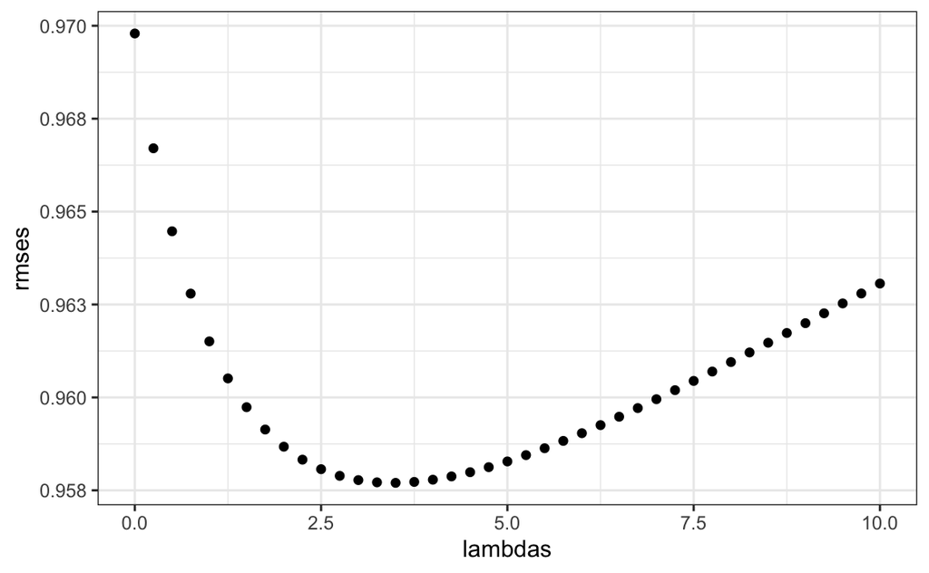

## Penalized least squares

- Once we select a \(\lambda\) we can compute the regularized estimates:

```r
b_i <- colSums(mat - mu, na.rm = TRUE) / (n + lambda)
```

- To see how the estimates shrink, let’s make a plot of the regularized estimates versus the least squares estimates.

## Penalized least squares

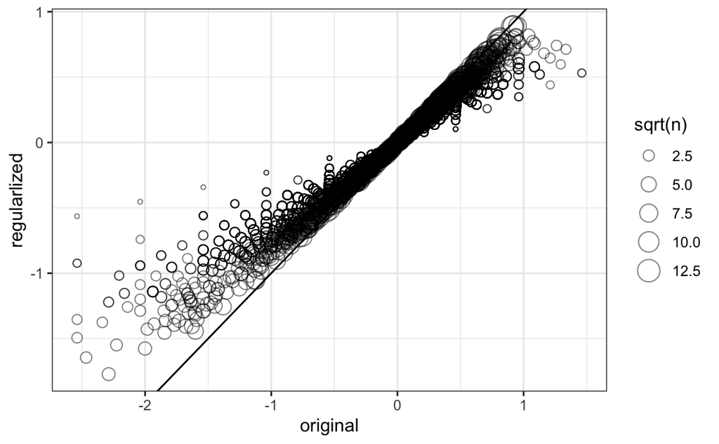

## Penalized least squares

- Now, let’s look at the top 3 best movies based on the penalized estimates \(\hat{b}_i(\lambda)\):

[output not shown]

- These make much more sense! These movies are watched more and have more ratings.

## Penalized least squares

- Do we improve our results? Let’s estimate the user effects with the new movie effect estimates and compute the new RMSE:

```r
fit_users$b_u <- rowMeans(sweep(mat - mu, 2, b_i), na.rm = TRUE)
left_join(test_set, fit_reg_movies, by = "movieId") |>
  left_join(fit_users, by = "userId") |>
  mutate(pred = mu + b_i + b_u) |>
  summarize(rmse = RMSE(rating, pred))
```

```
#> # A tibble: 1 × 1
#>    rmse
#>   <dbl>
#> 1 0.872
```

## Penalized least squares

- The penalized estimates provide an improvement over the least squares estimates:

| method | RMSE |
| --- | --- |
| Just the average | 1.044 |
| Movie Effect Model | 0.970 |
| Movie + User Effects Model | 0.885 |
| Regularized Movie + User Effect Model | 0.872 |

## Matrix factorization

- Matrix factorization is a widely used concept in machine learning.
- It is very much related to factor analysis, singular value decomposition (SVD), and principal component analysis (PCA).
- Here we describe the concept in the context of movie recommendation systems.

## Matrix factorization

- We have described how the model:

\[ Y_{u,i} = \mu + b_i + b_u + \varepsilon_{u,i} \]

- accounts for movie to movie differences through the \(b_i\) and user to user differences through the \(b_u\).
- But this model leaves out an important source of variation related to the fact that groups of movies have similar rating patterns and groups of users have similar rating patterns as well.
- We will discover these patterns by studying the residuals:

\[ r_{u,i} = y_{u,i} - \hat{b}_i - \hat{b}_u \]

## Matrix factorization

- We can compute these residuals for the model we fit in the previous section:

```r
r <- sweep(mat - mu, 2, fit_reg_movies$b_i) - fit_users$b_u
colnames(r) <- with(movie_map, title[match(colnames(r), movieId)])
```

- If the movie and user effect model explains all the signal, and the \(\varepsilon\) are just noise, then the residuals for different movies should be independent from each other.
- But they are not.

## Matrix factorization

- Here are some examples:

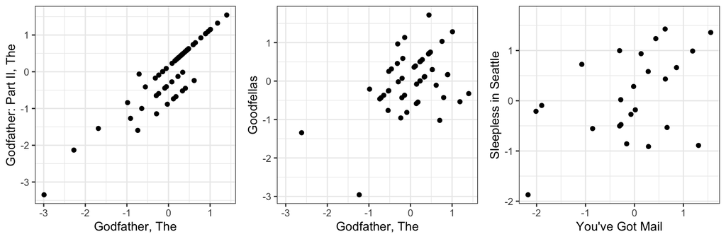

## Matrix factorization

- This plot says that users that liked The Godfather more than what the model expects them to, based on the movie and user effects, also liked The Godfather II more than expected.
- A similar relationship is seen when comparing The Godfather and Goodfellas.
- Although not as strong, there is still correlation.
- We see correlations between You’ve Got Mail and Sleepless in Seattle as well.

## Matrix factorization

- By looking at the correlation between movies, we can see a pattern (we rename the columns to save print space):

```
#>            Godfather Godfather2 Goodfellas You've Got Sleepless
#> Godfather      1.000      0.910      0.450     -0.453    -0.267
#> Godfather2     0.910      1.000      0.434     -0.242    -0.165
#> Goodfellas     0.450      0.434      1.000     -0.455    -0.359
#> You've Got    -0.453     -0.242     -0.455      1.000     0.450
#> Sleepless     -0.267     -0.165     -0.359      0.450     1.000
```

- There seems to be people that like romantic comedies more than expected, while others that like gangster movies more than expected.
- These results tell us that there is structure in the data.
- But how can we model this?
- We show an illustration, using a simulation, of how we can use some structure to predict the \(r_{u,i}\).

## Factor analysis

- Suppose our residuals `r` look like this:

```r
round(r, 1)
```

```
#>    Godfather Godfather2 Goodfellas You've Got Sleepless
#> 1        2.0        2.3        2.2       -1.8      -1.9
#> 2        2.0        1.7        2.0       -1.9      -1.7
#> 3        1.9        2.4        2.1       -2.3      -2.0
#> 4       -0.3        0.3        0.3       -0.4      -0.3
#> 5       -0.3       -0.4        0.3        0.2       0.3
#> 6       -0.1        0.1        0.2       -0.3       0.2
#> 7       -0.1        0.0       -0.2       -0.2       0.3
#> 8        0.2        0.2        0.1        0.0       0.4
#> 9       -1.7       -2.1       -1.8        2.0       2.4
#> 10      -2.3       -1.8       -1.7        1.8       1.7
#> 11      -1.7       -2.0       -2.1        1.9       2.3
#> 12      -1.8       -1.7       -2.1        2.3       2.0
```

- There seems to be a pattern here.

## Factor analysis

- In fact, we can see very strong correlation patterns:

```r
cor(r)
```

```
#>            Godfather Godfather2 Goodfellas You've Got Sleepless
#> Godfather      1.000      0.980      0.978     -0.974    -0.966
#> Godfather2     0.980      1.000      0.983     -0.987    -0.992
#> Goodfellas     0.978      0.983      1.000     -0.986    -0.989
#> You've Got    -0.974     -0.987     -0.986      1.000     0.986
#> Sleepless     -0.966     -0.992     -0.989      0.986     1.000
```

## Factor analysis

- We can create vectors `q` and `p`, that can explain much of the structure we see.
- The `q` would look like this:

```r
t(q)
```

```
#>      Godfather Godfather2 Goodfellas You've Got Sleepless
#> [1,]         1          1          1         -1        -1
```

- and it narrows down movies to two groups: gangster (coded with 1) and romance (coded with -1).
- We can also reduce the users to three groups:

## Factor analysis

```r
t(p)
```

```
#>      1 2 3 4 5 6 7 8  9 10 11 12
#> [1,] 2 2 2 0 0 0 0 0 -2 -2 -2 -2
```

- those that like gangster movies and dislike romance movies (coded as 2), those that like romance movies and dislike gangster movies (coded as -2), and those that don’t care (coded as 0).
- The main point here is that we can almost reconstruct \(r\), which has 60 values, with a couple of vectors totaling 17 values.
- Note that `p` and `q` are equivalent to the patterns and weights we described earlier.

## Factor analysis

- If \(r\) contains the residuals for users \(u=1,\dots,12\) for movies \(i=1,\dots,5\) we can write the following mathematical formula for our residuals \(r_{u,i}\).

\[ r_{u,i} \approx p_u q_i \]

- This implies that we can explain more variability by modifying our previous model for movie recommendations to:

\[ Y_{u,i} = \mu + b_i + b_u + p_u q_i + \varepsilon_{u,i} \]

## Factor analysis

- However, we motivated the need for the \(p_u q_i\) term with a simple simulation.
- The structure found in data is usually more complex.
- For example, in this first simulation we assumed there were was just one factor \(p_u\) that determined which of the two genres movie \(u\) belongs to.
- But the structure in our movie data seems to be much more complicated than gangster movie versus romance.
- We may have many other factors.

## Factor analysis

- Here we present a slightly more complex simulation.
- We now add a sixth movie.

```r
round(r, 1)
```

```
#>    Godfather Godfather2 Goodfellas You've Got Sleepless Scent
#> 1        0.5        0.6        1.6       -0.5      -0.5  -1.6
#> 2        1.5        1.4        0.5       -1.5      -1.4  -0.4
#> 3        1.5        1.6        0.5       -1.6      -1.5  -0.5
#> 4       -0.1        0.1        0.1       -0.1      -0.1   0.1
#> 5       -0.1       -0.1        0.1        0.0       0.1  -0.1
#> 6        0.5        0.5       -0.4       -0.6      -0.5   0.5
#> 7        0.5        0.5       -0.5       -0.6      -0.4   0.4
#> 8        0.5        0.6       -0.5       -0.5      -0.4   0.4
#> 9       -0.9       -1.0       -0.9        1.0       1.1   0.9
#> 10      -1.6       -1.4       -0.4        1.5       1.4   0.5
#> 11      -1.4       -1.5       -0.5        1.5       1.6   0.6
#> 12      -1.4       -1.4       -0.5        1.6       1.5   0.6
```

## Factor analysis

- By exploring the correlation structure of this new dataset.

```
#>            Godfather Godfather2 Goodfellas    YGM     SS     SW
#> Godfather      1.000      0.997      0.562 -0.997 -0.996 -0.571
#> Godfather2     0.997      1.000      0.577 -0.998 -0.999 -0.583
#> Goodfellas     0.562      0.577      1.000 -0.552 -0.583 -0.994
#> YGM           -0.997     -0.998     -0.552  1.000  0.998  0.558
#> SS            -0.996     -0.999     -0.583  0.998  1.000  0.588
#> SW            -0.571     -0.583     -0.994  0.558  0.588  1.000
```

- We note that we perhaps need a second factor to account for the fact that some users like Al Pacino, while others dislike him or don’t care.

## Factor analysis

- Notice that the overall structure of the correlation obtained from the simulated data is not that far off the real correlation:

```
#>            Godfather Godfather2 Goodfellas    YGM     SS      SW
#> Godfather      1.000      0.910     0.4500 -0.453 -0.267  0.2678
#> Godfather2     0.910      1.000     0.4342 -0.242 -0.165  0.1415
#> Goodfellas     0.450      0.434     1.0000 -0.455 -0.359 -0.0677
#> YGM           -0.453     -0.242    -0.4549  1.000  0.450 -0.0140
#> SS            -0.267     -0.165    -0.3594  0.450  1.000 -0.4340
#> SW             0.268      0.142    -0.0677 -0.014 -0.434  1.0000
```

## Factor analysis

- To explain this more complicated structure, we need two factors.
- For example something like this:

```r
t(q)
```

```
#>      Godfather Godfather2 Goodfellas You've Got Sleepless Scent
#> [1,]         1          1          1         -1        -1    -1
#> [2,]         1          1         -1         -1        -1     1
```

## Factor analysis

- With the first factor (the first row) used to code the gangster versus romance groups and a second factor (the second row) to explain the Al Pacino versus no Al Pacino groups.
- We will also need two sets of coefficients to explain the variability introduced by the \(3\times 3\) types of groups:

```r
t(p)
```

```
#>         1   2   3 4 5   6   7   8  9   10   11   12
#> [1,]  1.0 1.0 1.0 0 0 0.0 0.0 0.0 -1 -1.0 -1.0 -1.0
#> [2,] -0.5 0.5 0.5 0 0 0.5 0.5 0.5  0 -0.5 -0.5 -0.5
```

## Factor analysis

- The model with two factors has 36 parameters that can be used to explain much of the variability in the 72 ratings:

\[ Y_{u,i} = \mu + b_i + b_u + p_{u,1} q_{1,i} + p_{u,2} q_{2,i} + \varepsilon_{u,i} \]

## Factor analysis

- Note that in an actual data application, we need to fit this model to data.
- To explain the complex correlation we observe in real data, we usually permit the entries of \(p\) and \(q\) to be continuous values, rather than discrete ones as we used in the simulation.
- For example, rather than dividing movies into gangster or romance, we define a continuum.
- Also note that this is not a linear model and to fit it we need to use an algorithm other than the one used by `lm` to find the parameters that minimize the least squares.

## Factor analysis

- The winning algorithms for the Netflix challenge fit a model similar to the above and used regularization to penalize for large values of \(p\) and \(q\), rather than using least squares.
- Implementing this approach is beyond the scope of this class.

## Connection to SVD and PCA

- The decomposition:

\[ r_{u,i} \approx p_{u,1} q_{1,i} + p_{u,2} q_{2,i} \]

- is very much related to SVD and PCA.
- SVD and PCA are complicated concepts, but one way to understand them is that SVD is an algorithm that finds the vectors \(p\) and \(q\) that permit us to rewrite the matrix \(\mbox{r}\) with \(m\) rows and \(n\) columns as:

\[ r_{u,i} = p_{u,1} q_{1,i} + p_{u,2} q_{2,i} + \dots + p_{u,n} q_{n,i} \]

## Connection to SVD and PCA

- with the variability of each term decreasing and with the \(p\)s uncorrelated.
- The algorithm also computes this variability so that we can know how much of the matrices, total variability is explained as we add new terms.
- This may permit us to see that, with just a few terms, we can explain most of the variability.

## Connection to SVD and PCA

- To illustrate this we will only consider a small subset of movies with many ratings and users that have rated many movies:

```r
keep <- c("Godfather, The", "Godfather: Part II, The", "Goodfellas", "Ghost", "Titanic",
          "Scent of a Woman")
dat <- movielens  |>
  group_by(userId) |>
  filter(n() >= 250) |>
  ungroup() |>
  group_by(movieId) |>
  filter(n() >= 50 | title %in% keep) |>
  ungroup()
y <- select(dat, movieId, userId, rating) |>
  pivot_wider(names_from = movieId, values_from = rating)
y <- as.matrix(y[,-1])
colnames(y) <- dat |> select(movieId, title) |>
  distinct(movieId, .keep_all = TRUE) |>
  right_join(data.frame(movieId=as.integer(colnames(y))), by = "movieId") |>
  pull(title)
```

## Connection to SVD and PCA

- We first remove the overall movie and user effects as we are interested in the variability not explained by these.
- We start by removing the movie effects:

```r
r <- sweep(y, 2, colMeans(y, na.rm=TRUE))
```

- Because for the techniques shown here we can’t have missing values we need to replace the missing ratings.
- There are advanced techniques for doing this, some are exaplined in the description of the winning entry for the Netflix competition.
- Here we will use a simple approach: replace with a constant.

## Connection to SVD and PCA

- Now because an unrated movie is more likely to be a movie the user does not like, we will replace the missing ratings with -1 rather than a 0, which represents a neutral rating.

```r
r[is.na(r)] <- -1
```

- Finally we will remove the overall user effect:

```r
r <- r - rowMeans(r)
```

- Now we can perform principal component analysis:

```r
pca <- prcomp(r)
```

## Connection to SVD and PCA

- The \(q\) vectors are called the principal components and they are stored in this matrix:

```r
dim(pca$rotation)
```

```
#> [1] 138 105
```

- While the \(p\), or the user effects, are here:

```r
dim(pca$x)
```

```
#> [1] 105 105
```

- We can see the variability of each of the vectors:

```r
qplot(1:nrow(pca$x), pca$sdev, xlab = "PC")
```

## Connection to SVD and PCA

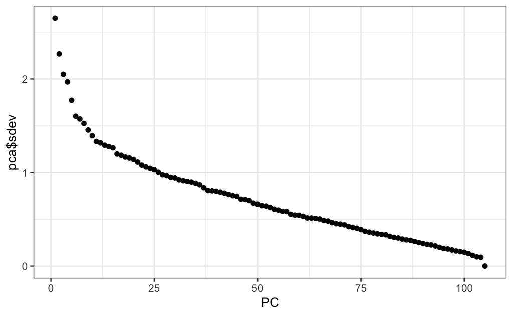

## Connection to SVD and PCA

- and see that just the first few already explain a large percent:

```r
var_explained <- cumsum(pca$sdev^2) / sum(pca$sdev^2)
qplot(1:nrow(pca$x), var_explained, xlab = "PC")  + ylim(c(0,1))
```

## Connection to SVD and PCA

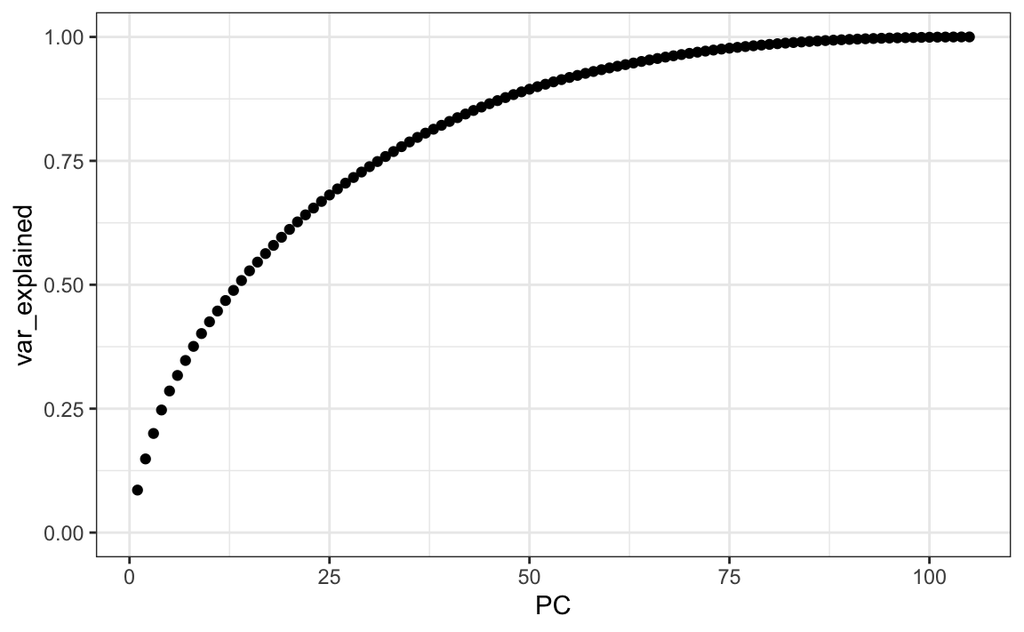

## Connection to SVD and PCA

- We also notice that the first two principal components are related to the structure in opinions about movies:

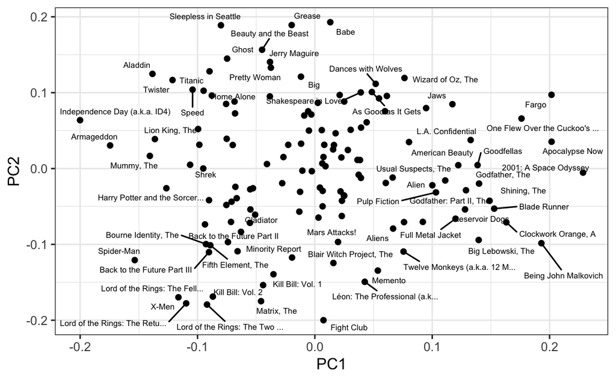

## Connection to SVD and PCA

- Just by looking at the top 10 in each direction, we see a meaningful pattern.
- The first PC shows the difference between Hollywood blockbusters on one side:

```
#>  [1] "Independence Day (a.k.a. ID4)"  "Armageddon"
#>  [3] "Spider-Man"                     "Mummy, The"
#>  [5] "Aladdin"                        "Lion King, The"
#>  [7] "Harry Potter and the Sorcer..." "Twister"
#>  [9] "X-Men"                          "Lord of the Rings: The Retu..."
```

## Connection to SVD and PCA

- and critically acclaimed movies on the other:

```
#>  [1] "2001: A Space Odyssey"          "Apocalypse Now"
#>  [3] "Fargo"                          "Being John Malkovich"
#>  [5] "One Flew Over the Cuckoo's ..." "Clockwork Orange, A"
#>  [7] "Blade Runner"                   "Shining, The"
#>  [9] "Godfather, The"                 "Big Lebowski, The"
```

## Connection to SVD and PCA

```
#>  [1] "Fight Club"                     "Lord of the Rings: The Two ..."
#>  [3] "Lord of the Rings: The Retu..." "Matrix, The"
#>  [5] "X-Men"                          "Lord of the Rings: The Fell..."
#>  [7] "Kill Bill: Vol. 2"              "Léon: The Professional (a.k..."
#>  [9] "Kill Bill: Vol. 1"              "Memento"
```

## Connection to SVD and PCA

- to romantic movies:

```
#>  [1] "Babe"                 "Grease"               "Sleepless in Seattle"
#>  [4] "Beauty and the Beast" "Ghost"                "Jerry Maguire"
#>  [7] "Pretty Woman"         "Titanic"              "Aladdin"
#> [10] "Big"
```

## Connection to SVD and PCA

- Fitting a model that incorporates these estimates is complicated.
- For those interested in implementing an approach that incorporates these ideas, we recommend trying the **recommenderlab** package.
- The details are beyond the scope of this book.